# Reproducible Research: Peer Assessment 1

Adrien ROUX

Thursday, December 17, 2015

## Loading and preprocessing the data

This assignment makes use of data from a personal activity monitoring device. This device collects data at 5 minute intervals through out the day. The data consists of two months of data from an anonymous individual collected during the months of October and November, 2012 and include the number of steps taken in 5 minute intervals each day.

```r
#we first unzip data and create a .csv file.
#we then load raw data from the newly created csv file.
unzip("activity.zip", exdir = ".")
rawData <- read.csv(file="activity.csv",header=T);

# take a first look at the raw data.
head(rawData);
```

```
##   steps       date interval
## 1    NA 2012-10-01        0
## 2    NA 2012-10-01        5
## 3    NA 2012-10-01       10
## 4    NA 2012-10-01       15
## 5    NA 2012-10-01       20
## 6    NA 2012-10-01       25
```

```r
str(rawData)
```

```
## 'data.frame':    17568 obs. of  3 variables:
##  $ steps   : int  NA NA NA NA NA NA NA NA NA NA ...
##  $ date    : Factor w/ 61 levels "2012-10-01","2012-10-02",..: 1 1 1 1 1 1 1 1 1 1 ...
##  $ interval: int  0 5 10 15 20 25 30 35 40 45 ...
```

The variables included in this dataset are:

- steps: Number of steps taking in a 5-minute interval (missing values are coded as NA)
- date: The date on which the measurement was taken in YYYY-MM-DD format
- interval: Identifier for the 5-minute interval in which measurement was taken

```r
library("lubridate");
rawData$date <- ymd(rawData$date)

# summary overview
str(rawData)
```

```
## 'data.frame':    17568 obs. of  3 variables:
##  $ steps   : int  NA NA NA NA NA NA NA NA NA NA ...
##  $ date    : POSIXct, format: "2012-10-01" "2012-10-01" ...
##  $ interval: int  0 5 10 15 20 25 30 35 40 45 ...
```

```r
summary(rawData)
```

```
##      steps             date               interval
##  Min.   :  0.00   Min.   :2012-10-01   Min.   :   0.0
##  1st Qu.:  0.00   1st Qu.:2012-10-16   1st Qu.: 588.8
##  Median :  0.00   Median :2012-10-31   Median :1177.5
##  Mean   : 37.38   Mean   :2012-10-31   Mean   :1177.5
##  3rd Qu.: 12.00   3rd Qu.:2012-11-15   3rd Qu.:1766.2
##  Max.   :806.00   Max.   :2012-11-30   Max.   :2355.0
##  NA's   :2304
```

## What is mean total number of steps taken per day?

For this part, we ignore the missing values in the dataset.

```r
totalNumberOfStepsPerDay <- with(rawData,tapply(steps,date,sum,na.rm=TRUE));

str(totalNumberOfStepsPerDay)
```

```
##  int [1:61(1d)] 0 126 11352 12116 13294 15420 11015 0 12811 9900 ...
##  - attr(*, "dimnames")=List of 1
##   ..$ : chr [1:61] "2012-10-01" "2012-10-02" "2012-10-03" "2012-10-04" ...
```

```r
summary(totalNumberOfStepsPerDay)
```

```
##    Min. 1st Qu.  Median    Mean 3rd Qu.    Max.
##       0    6778   10400    9354   12810   21190
```

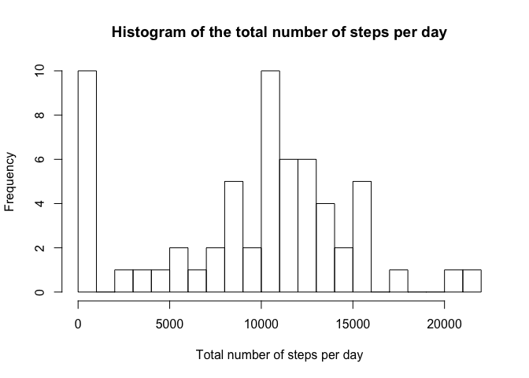

```r
hist(totalNumberOfStepsPerDay,breaks=30,
     xlab= "Total number of steps per day",
     main= "Histogram of the total number of steps per day")
```

```r
meanTotalNumberOfStepsPerDay <- mean(totalNumberOfStepsPerDay, na.rm = T);
medTotalNumberOfStepsPerDay <- median(totalNumberOfStepsPerDay, na.rm = T);
```

The **mean** total number of steps taken per day is 9354.2 steps, where as the **median** is 10395 steps.

## What is the average daily activity pattern?

Make a time series plot (i.e. type = “l”) of the 5-minute interval (x-axis) and the average number of steps taken, averaged across all days (y-axis)

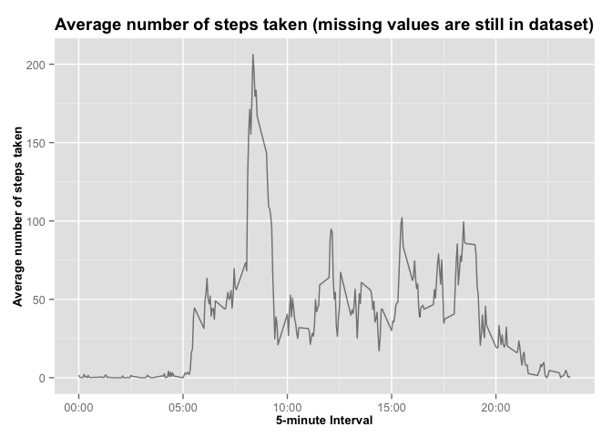

```r
library("ggplot2")
avgNumberOfStepsPerInterval <- aggregate(steps ~ interval, data=rawData, function(x){ return(mean(x,na.rm=T))});

g <- ggplot(avgNumberOfStepsPerInterval)
g <- g + geom_line(aes(x= interval, y=steps), alpha= 0.5, size= 0.5, color="black")
g <- g + xlab("5-minute Interval");
g <- g + ylab("Average number of steps taken");
g <- g + ggtitle("Average number of steps taken (missing values are still in dataset)");
g <- g + theme(plot.title = element_text(face="bold", colour="black", size=14, vjust = 1))
g <- g + theme(axis.title.x = element_text(face="bold", colour="black", size=10))
g <- g + theme(axis.title.y = element_text(face="bold", colour="black", size=10))
g <- g + scale_x_continuous(label=function(x){
    min = x %% 100;
    hour = (x - min)/100;
    return( sprintf("%02d:%02d", hour, min))})
g
```

```r
max5MinInterval <- avgNumberOfStepsPerInterval$interval[avgNumberOfStepsPerInterval$steps == max(avgNumberOfStepsPerInterval$steps)];
```